# Worksheet 4: Support Vector Machines

Ruman Sidhu

Due April 24, 2026

## Exercise 1

Return to Exercise 1 from Worksheet 3. Using the same OJ data set, copy your previous results from parts (a)-(e) and paste them here.

```r
library(e1071)
library(ISLR2)

# Previous results from Parts (a)-(e):

# (a) Create train/test split
set.seed(5322)
trainid <- sample(1:nrow(OJ), 800)
oj.train <- OJ[trainid,]
oj.test <- OJ[-trainid,]

# (b) Fit SVC with cost = 0.01
svcoj <- svm(Purchase ~ ., data = oj.train, kernel = "linear", cost = 0.01)
summary(svcoj)
```

```
##
## Call:
## svm(formula = Purchase ~ ., data = oj.train, kernel = "linear", cost = 0.01)
##
##
## Parameters:
##    SVM-Type:  C-classification
##  SVM-Kernel:  linear
##        cost:  0.01
##
## Number of Support Vectors:  443
##
##  ( 220 223 )
##
##
## Number of Classes:  2
##
## Levels:
##  CH MM
```

```r
# (c) Training and test errors
sum(predict(svcoj, oj.train) != oj.train$Purchase) / nrow(oj.train)
```

```
## [1] 0.16875
```

```r
sum(predict(svcoj, oj.test) != oj.test$Purchase) / nrow(oj.test)
```

```
## [1] 0.1592593
```

```r
# (d) Tune for best cost
tune.out <- tune(svm, Purchase ~ ., data = oj.train, kernel = "linear",
    ranges = list(cost = c(0.01, 0.1, 1, 5, 10)))
tune.out$best.parameters
```

```
##   cost
## 2  0.1
```

```r
# (e) Errors with best cost
sum(predict(tune.out$best.model, oj.train) != oj.train$Purchase) / nrow(oj.train)
```

```
## [1] 0.16375
```

```r
sum(predict(tune.out$best.model, oj.test) != oj.test$Purchase) / nrow(oj.test)
```

```
## [1] 0.1555556
```

6. Repeat parts (b) through (e) using a support vector machine with a radial kernel. Use the default value for gamma.

```r
# Step 1: Fit with cost = 0.01, radial kernel
set.seed(5322)
svm_radial <- svm(Purchase ~ ., data = oj.train, kernel = "radial", cost = 0.01)
summary(svm_radial)
```

```
##
## Call:
## svm(formula = Purchase ~ ., data = oj.train, kernel = "radial", cost = 0.01)
##
##
## Parameters:
##    SVM-Type:  C-classification
##  SVM-Kernel:  radial
##        cost:  0.01
##
## Number of Support Vectors:  633
##
##  ( 315 318 )
##
##
## Number of Classes:  2
##
## Levels:
##  CH MM
```

```r
# Step 2: Training and test errors
sum(predict(svm_radial, oj.train) != oj.train$Purchase) / nrow(oj.train)
```

```
## [1] 0.39375
```

```r
sum(predict(svm_radial, oj.test) != oj.test$Purchase) / nrow(oj.test)
```

```
## [1] 0.3777778
```

```r
# Step 3: Tune for best cost
set.seed(5322)
tune_radial <- tune(svm, Purchase ~ ., data = oj.train, kernel = "radial",
    ranges = list(cost = c(0.01, 0.1, 1, 5, 10)))
tune_radial$best.parameters
```

```
##   cost
## 4    5
```

```r
# Step 4: Errors with best cost
sum(predict(tune_radial$best.model, oj.train) != oj.train$Purchase) / nrow(oj.train)
```

```
## [1] 0.15
```

```r
sum(predict(tune_radial$best.model, oj.test) != oj.test$Purchase) / nrow(oj.test)
```

```
## [1] 0.1592593
```

The radial SVM with cost = 0.01 performed poorly, with a training error of 39.4% and test error of 37.8%. After tuning, cost = 5 was selected, which brought training error down to 15% and test error to 15.9%.

7. Repeat parts (b) through (e) using a support vector machine with a polynomial kernel. Set degree = 2.

```r
# Step 1: Fit with cost = 0.01, polynomial kernel
set.seed(5322)
svm_poly <- svm(Purchase ~ ., data = oj.train, kernel = "polynomial",
                degree = 2, cost = 0.01)
summary(svm_poly)
```

```
##
## Call:
## svm(formula = Purchase ~ ., data = oj.train, kernel = "polynomial",
##     degree = 2, cost = 0.01)
##
##
## Parameters:
##    SVM-Type:  C-classification
##  SVM-Kernel:  polynomial
##        cost:  0.01
##      degree:  2
##      coef.0:  0
##
## Number of Support Vectors:  635
##
##  ( 315 320 )
##
##
## Number of Classes:  2
##
## Levels:
##  CH MM
```

```r
# Step 2: Training and test errors
sum(predict(svm_poly, oj.train) != oj.train$Purchase) / nrow(oj.train)
```

```
## [1] 0.375
```

```r
sum(predict(svm_poly, oj.test) != oj.test$Purchase) / nrow(oj.test)
```

```
## [1] 0.3555556
```

```r
# Step 3: Tune for best cost
set.seed(5322)
tune_poly <- tune(svm, Purchase ~ ., data = oj.train, kernel = "polynomial",
    degree = 2, ranges = list(cost = c(0.01, 0.1, 1, 5, 10)))
tune_poly$best.parameters
```

```
##   cost
## 5   10
```

```r
# Step 4: Errors with best cost
sum(predict(tune_poly$best.model, oj.train) != oj.train$Purchase) / nrow(oj.train)
```

```
## [1] 0.1525
```

```r
sum(predict(tune_poly$best.model, oj.test) != oj.test$Purchase) / nrow(oj.test)
```

```
## [1] 0.162963
```

The polynomial SVM with degree = 2 and cost = 0.01 also performed poorly, with a training error of 37.5% and test error of 35.6%. After tuning, cost = 10 was selected as optimal, improving performance to a training error of 15.25% and test error of 16.3%.

8. Overall, which approach seems to give the best results on this data?

===

## Exercise 2

Return to Exercise 2 from Worksheet 3. Using the same Auto data set, copy your previous results from parts (a)-(c) and paste them here.

4. Now repeat (b), this time using SVMs with radial and polynomial basis kernels, with different values of gamma and degree and cost. Comment on your results.

```r
library(e1071)
library(ISLR2)
library(tidyverse)
# (a) Create binary variable and clean data
myauto <- Auto %>%
  select(-c(mpg, name, origin)) %>%
  scale() %>%
  data.frame()

myauto$mpgbinary <- ifelse(Auto$mpg > median(Auto$mpg), 1, 0) %>% as.factor

# (b) Fit SVC and tune for best cost
set.seed(5322)
autotune <- tune(svm, mpgbinary ~ ., data = myauto, kernel = "linear",
    ranges = list(cost = c(0.001, 0.01, 0.1, 1, 5, 10, 100)))
autotune$performances
```

```
##    cost      error dispersion
## 1 1e-03 0.19147436 0.07210331
## 2 1e-02 0.08435897 0.04380311
## 3 1e-01 0.09717949 0.04346828
## 4 1e+00 0.09461538 0.05008959
## 5 5e+00 0.08692308 0.04406913
## 6 1e+01 0.08692308 0.04406913
## 7 1e+02 0.08948718 0.04416848
```

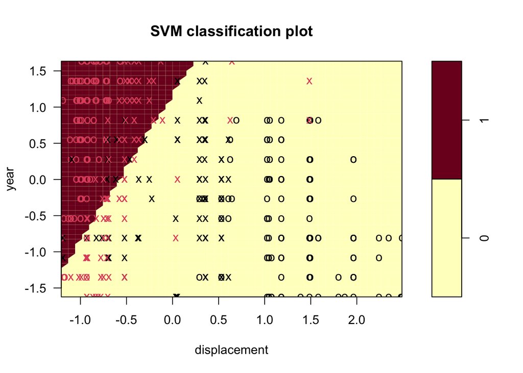

```r
b <- autotune$best.model

# (c) Plot
plot(b, myauto, year ~ displacement)
```

```r
# Radial kernel - tune gamma and cost
set.seed(5322)
tune_radial <- tune(svm, mpgbinary ~ ., data = myauto, kernel = "radial",
    ranges = list(cost = c(0.01, 0.1, 1, 5, 10),
                  gamma = c(0.01, 0.1, 1, 5)))
tune_radial$best.parameters
```

```
##    cost gamma
## 14    5     1
```

```r
tune_radial$performances
```

```
##     cost gamma      error dispersion
## 1   0.01  0.01 0.57929487 0.04612025
## 2   0.10  0.01 0.12506410 0.04263070
## 3   1.00  0.01 0.09461538 0.04550449
## 4   5.00  0.01 0.09974359 0.04289308
## 5  10.00  0.01 0.09461538 0.04386976
## 6   0.01  0.10 0.16839744 0.09303393
## 7   0.10  0.10 0.09461538 0.04217171
## 8   1.00  0.10 0.08692308 0.04406913
## 9   5.00  0.10 0.08179487 0.04311710
## 10 10.00  0.10 0.08948718 0.05013606
## 11  0.01  1.00 0.57929487 0.04612025
## 12  0.10  1.00 0.10487179 0.04620546
## 13  1.00  1.00 0.07416667 0.03734129
## 14  5.00  1.00 0.06891026 0.01737286
## 15 10.00  1.00 0.06891026 0.03432830
## 16  0.01  5.00 0.57929487 0.04612025
## 17  0.10  5.00 0.53384615 0.08840929
## 18  1.00  5.00 0.08166667 0.03582639
## 19  5.00  5.00 0.08160256 0.04480668
## 20 10.00  5.00 0.08160256 0.04480668
```

```r
# Polynomial kernel - tune degree and cost
set.seed(5322)
tune_poly <- tune(svm, mpgbinary ~ ., data = myauto, kernel = "polynomial",
    ranges = list(cost = c(0.01, 0.1, 1, 5, 10),
                  degree = c(2, 3, 4)))
tune_poly$best.parameters
```

```
##    cost degree
## 10   10      3
```

```r
tune_poly$performances
```

```
##     cost degree      error dispersion
## 1   0.01      2 0.45903846 0.07423143
## 2   0.10      2 0.27544872 0.07084489
## 3   1.00      2 0.25762821 0.07850606
## 4   5.00      2 0.24487179 0.09351263
## 5  10.00      2 0.25500000 0.07783047
## 6   0.01      3 0.26269231 0.07694966
## 7   0.10      3 0.21185897 0.09391275
## 8   1.00      3 0.11237179 0.03472344
## 9   5.00      3 0.09448718 0.03189306
## 10 10.00      3 0.08423077 0.03175533
## 11  0.01      4 0.36967949 0.08428671
## 12  0.10      4 0.27032051 0.07113816
## 13  1.00      4 0.26532051 0.07271519
## 14  5.00      4 0.25256410 0.07777367
## 15 10.00      4 0.27576923 0.07212088
```

For the radial kernel, tuning over different values of cost and gamma found that cost = 5 and gamma = 1 gave the best cross-validation performance. For the polynomial kernel, cost = 10 and degree = 3 performed best. Both nonlinear kernels performed similarly to the linear SVC from part (b), which had a best error of 8.4%. The radial kernel achieved a slightly lower error, suggesting it captures the data structure marginally better than the linear or polynomial kernels on this dataset.

5. Make some plots to back up your assertions in (b) and (d).

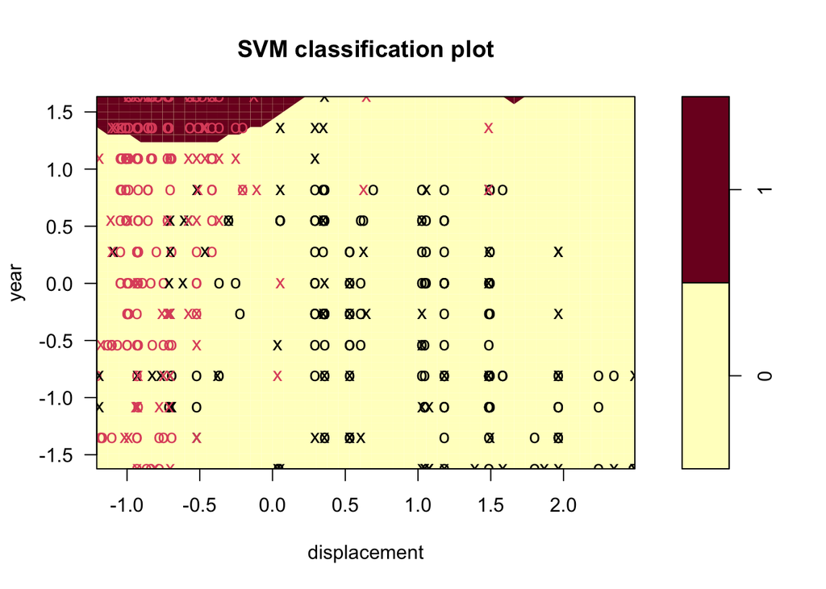

```r
# Plot for best radial model
plot(tune_radial$best.model, myauto, year ~ displacement)
```

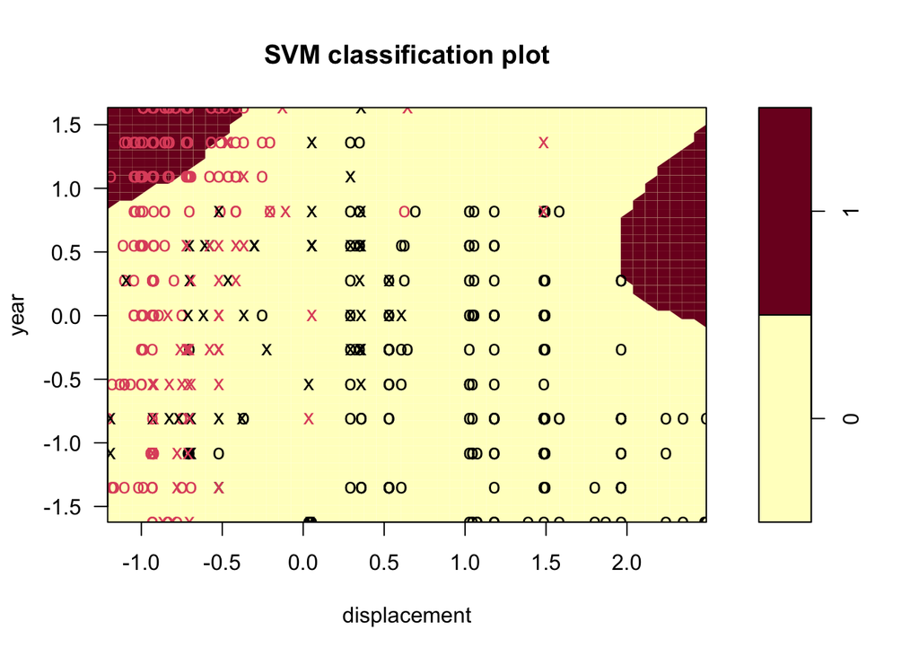

```r
# Plot for best polynomial model
plot(tune_poly$best.model, myauto, year ~ displacement)
```

The radial kernel plot shows a more complex, curved decision boundary compared to the linear SVC from part (c). The polynomial kernel plot also shows a nonlinear boundary with a distinctive curved shape in the upper right corner. Both plots confirm that the nonlinear kernels are capturing more complex patterns in the data, though the boundaries are still not perfectly clean due to the overlapping nature of the two classes.

===

## Exercise 3

1. Generate a data set with n = 500 and p = 2, such that the observations belong to two classes with a quadratic decision boundary between them. For instance, you can do this as follows: > x1 <- runif (500) - 0.5 > x2 <- runif (500) - 0.5 > y <- 1 * (x1^2 - x2^2 > 0)

```r
set.seed(5322)
x1 <- runif(500) - 0.5
x2 <- runif(500) - 0.5
y <- 1 * (x1^2 - x2^2 > 0)
```

2. Plot the observations, colored according to their class labels. Your plot should display X1 on the x-axis, and X2 on the y-axis.

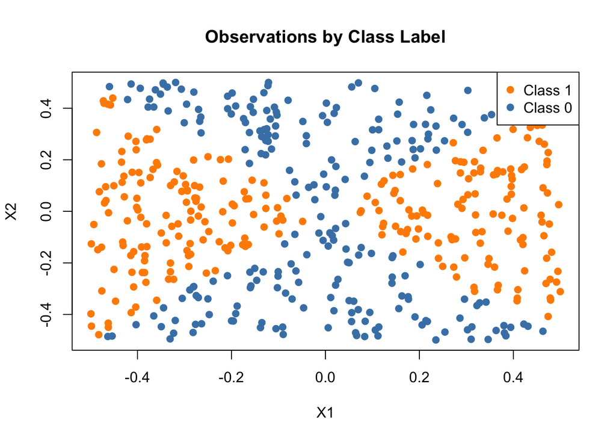

```r
plot(x1, x2, col = ifelse(y == 1, "darkorange", "steelblue"),
     xlab = "X1", ylab = "X2", pch = 19,
     main = "Observations by Class Label")
legend("topright", legend = c("Class 1", "Class 0"),
       col = c("darkorange", "steelblue"), pch = 19)
```

The plot shows two classes separated by a quadratic decision boundary. The classes form diagonal band patterns, reflecting the quadratic relationship x1^2 - x2^2 > 0 used to generate the data.

3. Fit a support vector classifier to the data with X1 and X2 as predictors. Obtain a class prediction for each training observation. Plot the observations, colored according to the predicted class labels.

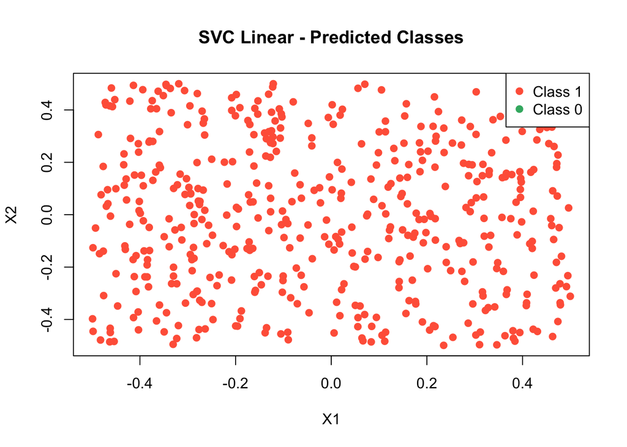

```r
dat <- data.frame(x1 = x1, x2 = x2, y = as.factor(y))

set.seed(5322)
svc_linear <- svm(y ~ ., data = dat, kernel = "linear", cost = 0.01)

# Plot predicted classes
pred_linear <- predict(svc_linear, dat)
plot(x1, x2, col = ifelse(pred_linear == 1, "tomato", "mediumseagreen"),
     xlab = "X1", ylab = "X2", pch = 19,
     main = "SVC Linear - Predicted Classes")
legend("topright", legend = c("Class 1", "Class 0"),
       col = c("tomato", "mediumseagreen"), pch = 19)
```

The linear SVC classifies almost all observations as Class 1, shown by the near-uniform tomato color. This is expected since a linear boundary cannot capture the quadratic decision boundary used to generate the data.

4. Fit a SVM using a non-linear kernel to the data. Obtain a class prediction for each training observation. Plot the observations, colored according to the predicted class labels.

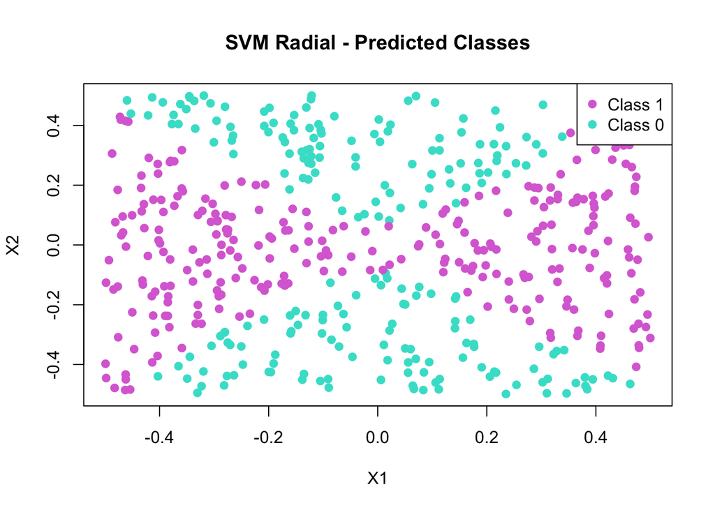

```r
set.seed(5322)
svm_radial <- svm(y ~ ., data = dat, kernel = "radial", cost = 1)

# Plot predicted classes
pred_radial <- predict(svm_radial, dat)
plot(x1, x2, col = ifelse(pred_radial == 1, "orchid", "turquoise"),
     xlab = "X1", ylab = "X2", pch = 19,
     main = "SVM Radial - Predicted Classes")
legend("topright", legend = c("Class 1", "Class 0"),
       col = c("orchid", "turquoise"), pch = 19)
```

The radial SVM does a much better job of capturing the quadratic decision boundary, showing a clear mix of both classes with a nonlinear separation pattern. This is a significant improvement over the linear SVC which classified almost everything as Class 1.

5. Which model performs better on the training data? Which model performs better on the test data? Make plots and report training and test error rates in order to back up your assertions.

```r
set.seed(5322)
train_id <- sample(1:500, 400)
dat_train <- dat[train_id, ]
dat_test <- dat[-train_id, ]

# Fit both models on training data
svc_train <- svm(y ~ ., data = dat_train, kernel = "linear", cost = 0.01)
svm_train <- svm(y ~ ., data = dat_train, kernel = "radial", cost = 1)

# Training errors
train_err_linear <- sum(predict(svc_train, dat_train) != dat_train$y) / nrow(dat_train)
train_err_radial <- sum(predict(svm_train, dat_train) != dat_train$y) / nrow(dat_train)

# Test errors
test_err_linear <- sum(predict(svc_train, dat_test) != dat_test$y) / nrow(dat_test)
test_err_radial <- sum(predict(svm_train, dat_test) != dat_test$y) / nrow(dat_test)

train_err_linear
```

```
## [1] 0.465
```

```r
train_err_radial
```

```
## [1] 0.035
```

```r
test_err_linear
```

```
## [1] 0.44
```

```r
test_err_radial
```

```
## [1] 0.05
```

The radial SVM wins on both training and test data. The linear SVC has a training error of 46.5% and test error of 44%, which is basically coin-flip territory. That’s expected since the true boundary here is quadratic and a straight line can’t capture it. The radial kernel gets 3.5% training error and 5% test error, so it fits well and still generalizes. The plots back this up visually too.

===

## Exercise 4

This exercise uses the penguin data from the palmerpenguins package.

1. Load in the `penguins` data set and save it as a new variable. Remove the `sex`, `island` and `year` variables as well as NA values. Create a training set and test set with a 70/30 split.

```r
library(palmerpenguins)
penguins_clean <- na.omit(penguins[, !names(penguins) %in% c("sex", "island", "year")])

set.seed(5322)
train_id <- sample(1:nrow(penguins_clean), 0.7 * nrow(penguins_clean))
pen_train <- penguins_clean[train_id, ]
pen_test  <- penguins_clean[-train_id, ]
```

The penguins dataset is loaded from the palmerpenguins package. The variables sex, island, and year are removed since they are not useful for classifying species. Rows with NA values are dropped to avoid issues during model fitting. The cleaned dataset is split into 70% training and 30% test using seed 5322.

2. Make a multi-class support vector classifier to classify species. Tune for a few values of cost to ensure your model is reasonable.

```r
set.seed(5322)
tune_linear <- tune(svm, species ~ ., data = pen_train,
                    kernel = "linear",
                    ranges = list(cost = c(0.01, 0.1, 1, 5, 10)))

tune_linear$best.parameters
```

```
##   cost
## 3    1
```

```r
tune_linear$best.performance
```

```
## [1] 0.01268116
```

```r
best_svc <- tune_linear$best.model
train_pred_svc <- predict(best_svc, pen_train)
test_pred_svc <- predict(best_svc, pen_test)

train_err_svc <- mean(train_pred_svc != pen_train$species)
test_err_svc <- mean(test_pred_svc != pen_test$species)

train_err_svc
```

```
## [1] 0.0125523
```

```r
test_err_svc
```

```
## [1] 0.009708738
```

A linear SVC is fit to the training data using cross-validation across cost values of 0.01, 0.1, 1, 5, and 10. The optimal cost selected is 1 with a cross-validation error of about 1.3%. The model achieves a training error of 1.26% and a test error of 0.97%, which suggests the linear kernel separates penguin species very well with minimal overfitting.

3. Make a multi-class SVM with a nonlinear kernel to classify species. Tune the appropriate parameters to ensure your model is reasonable.

```r
set.seed(5322)
tune_radial <- tune(svm, species ~ ., data = pen_train,
                    kernel = "radial",
                    ranges = list(cost = c(0.1, 1, 5, 10),
                                  gamma = c(0.01, 0.1, 1, 5)))

tune_radial$best.parameters
```

```
##   cost gamma
## 6    1   0.1
```

```r
tune_radial$best.performance
```

```
## [1] 0.01268116
```

```r
best_svm <- tune_radial$best.model
train_err_svm <- mean(predict(best_svm, pen_train) != pen_train$species)
test_err_svm <- mean(predict(best_svm, pen_test) != pen_test$species)

train_err_svm
```

```
## [1] 0.0125523
```

```r
test_err_svm
```

```
## [1] 0.009708738
```

A radial SVM is fit using cross-validation over cost values of 0.1, 1, 5, and 10, and gamma values of 0.01, 0.1, 1, and 5. The best combination is cost = 1 and gamma = 0.1, with a CV error of 1.27%. Training error comes out to 1.26% and test error to 0.97%, which is essentially the same performance as the linear SVC. This makes sense since penguin species are likely well-separated in feature space, so both kernels can find a clean boundary.

4. Comment on the differences between the models. How do they compare in training error? What about test error? Using the optimal values of your hyperparameters for each, rerun each model and time it using the tictoc package. How long did they each take to run?

```r
library(tictoc)

tic()
svc_final <- svm(species ~ ., data = pen_train, kernel = "linear", cost = 1)
toc()
```

```
## 0.001 sec elapsed
```

```r
tic()
svm_final <- svm(species ~ ., data = pen_train, kernel = "radial", cost = 1, gamma = 0.1)
toc()
```

```
## 0.001 sec elapsed
```